# Ch3 - Classification: Spam Filtering

Steve Newns

November 8, 2017

# This or That: Binary Classification

A separating hyperplane **decision boundary** b/c typically working w/ data that can’t be classified properly using only straight lines.

Producing general-purpose tools that handle problems where a decision boundary isn’t a single straight line has been 1 of the great achievements of ML

1 approach in particular = the **kernel trick** = has remarkable property of allowing us to work w/ much more sophisticated decision boundaries at almost no additional computational cost (coming later)

Assume we have a set of labeled examples of categories we want to learn how to ID that consist of a label/class + a series of measured variables that *describe* each example = **features/predictors**

Examples of classifications can be found anywhere you look for them:

- Given the results of a mammogram, does a patient have breast cancer?
- Do blood pressure measurements suggest that a patient has hypertension?
- Does a political candidate’s platform suggest she is a Republican or Democratic candidate?
- Does a picture uploaded to a social network contain a face in it?
- Was The Tempest written by William Shakespeare or Francis Bacon?

# Build a system for deciding whether an email is spam or ham.

Raw data comes from `SpamAssassin` public **corpus**, available for free download @ http://spamassassin.apache.org/old/publiccorpus/.

At the unprocessed stage, features = simply the contents of the raw email as plain text which provides us w/ our 1st problem = need to transform our *raw text* data into a set of **features that describe qualitative concepts in a quantitative way**.

In our case, that will be a 0/1 coding strategy: `spam` or `ham`

May want to determine if containing HTML tags make an email more likely to be spam. To answer this, we need a strategy for turning the text in email into numbers.

Fortunately, general-purpose text-mining packages available in R will do much of this work for us so we can focus on building up intuition for types of features people have used in the past when working w/ text data.

**Feature generation/engineering** = a major topic in current ML research + is still very far from being automated in a general-purpose way. At present, it’s best to think of the features being used as part of a vocabulary of ML that you become more familiar w/ as you perform more ML tasks.

**Just as learning words of a new language builds up an intuition for what could realistically be a word, learning about the features people have used in the past builds up an intuition for what features could reasonably be helpful in the future.**

When working w/ text, historically the most important type of feature used = word count. If we think text of HTML tags are strong indicators of if email is spam, we might pick terms like “html” + “table” + count how often they occur in 1 type of document vs. the other.

A plot of points might not be very informative if too many DPs overlap (comes up quite often w/ data that contains only a few unique values for 1+ variables). As this is a recurring problem, there is a standard graphical solution: simply add random noise to plotted values which will “separate out” the points to reduce amount of over-plotting = **jittering**

In practice, we can do a much better job by using many more than just these 2 very obvious terms like “html” and “table”. The final analysis uses several thousand terms + even though we’ll only use word-count data, we’ll still get a relatively accurate classification.

In the real world, you’d want to use other features beyond word counts, like falsified headers, IP or email black lists, etc., but here we only want to introduce the basics of text classification.

# Moving Gently into Conditional Probability

At its core, text classification = 20th-century application of the 18th-century concept of **conditional probability** = likelihood of observing 1 thing *given some other thing already known* like probability a college student is female given we already know the student’s major is CS.

According to a National Science Foundation survey in 2005, only 22% of undergrad CS majors were female but 51% of undergrad science majors overall were female, so conditioning on being a CS major lowers chances of being a woman from 51% to 22%.

**Naive Bayes classifier** = looks for differences of this sort by searching through text for words that are either:

- noticeably more likely to occur in spam messages
- noticeably more likely to occur in ham messages.

When a word is noticeably more likely to occur in 1 context rather than the other, its occurrence can be diagnostic of whether a new message is spam or ham. The logic is simple: if you see a single word more likely to occur in spam than ham = evidence the email as a whole is spam. If you see *many* words more likely to occur in spam than ham + very few words more likely to occur in ham than spam = strong evidence the email as a whole is spam.

Ultimately, our text classifier formalizes this intuition by computing

- probability of seeing exact contents of an email conditioned on the email being assumed to be spam
- probability of seeing the same email’s contents conditioned on the email being assumed to be ham.

If it’s much more likely that we’d see the email in question if it were spam, declare it to be spam.

How much more likely a message needs to be to merit being labeled spam depends upon an additional piece of info: the **base rate** of seeing spam messages = the **prior**

W/ email, prior comes into play b/c the majority of email sent is spam, which means even weak evidence an email is spam can be sufficient to justify labeling it as spam.

To compute probability of an email, assume the occurrence counts for every word can be estimated in isolation from all of the other words = **statistical independence**.

When we make this assumption w/out being certain it’s correct, we say our model is **naive.** B/c we also make use of base rate info about spam, the model is also a **Bayes model**. Ttogether, these 2 traits make a **Naive Bayes classifier**.

# Writing Our First Bayesian Spam Classifier

`SpamAssassin` public corpus consists of labeled emails from 3 categories: “spam,” “easy ham,” + “hard ham.” (more difficult to distinguish from spam than easy stuff + often includes HTML tags, which is 1 way to easily ID spam)

To more accurately classify hard ham, we must to include more info from many more text features + extracting these features requires some **text mining** of the email files + constitutes our initial step in creating a classifier.

All raw email files include headers + message text. Header contains a lot of info about where an email comes from. Despite the fact there is a lot of useful info contained in the headers, we will not be using any of this info in our classifier.

Rather than focus on features contained in the *transmission* of the message, we’re interested in how the *contents* of messages themselves can help predict an email’s type (not to say one should always ignore the header or any other info as all sophisticated modern spam filters utilize info contained in email message headers, such as whether portions of it appear to have been forged, whether the message is from a known spammer, or whether there are bits missing)

B/c we’re focusing on only the email message/body, we need to extract this text from the message files, which always begin after the 1st full line break in the email file.

To begin building our classifier, 1st create R functions that can access the files + extract the message text by taking advantage of this text convention.

```r
library(tidyverse)
library(tm) # text mining
library(ggplot2)
library(magrittr)

spam_path <- "./data/spam/"
spam2_path <- "./data/spam_2/"
easyham_path <- "./data/easy_ham/"
easyham2_path <- "./data/easy_ham_2/"
hardham_path <- "./data/hard_ham/"
hardham2_path <- "./data/hard_ham_2/"
```

Now to create text corpuses from both sets of files via function that opens each file, finds the 1st line break, + returns the text below that break as a character vector w/ a single text element.

```r
get_msg <- function(path) {
  # Function to grab all text after
  # 1st line break in a text file
  # and returns it in a character vector

  #open connection and read in the lines, each as seperate element of character vector
  connection <- file(path, open = "rt")#, encoding = "latin1")
  text <- readLines(path)

  # find 1st line break (1st empty element) and get all text after this position
  # get index of 1st empty element, add 1, + generate all indexes from this to the end
  from <- which(text == "")[1] + 1
  to <- length(text)
  msg <- text[seq(from, to, 1)]
  close(connection)

  # get vector into a single character vector
  return(paste(msg, collapse = "\n"))
}
```

To train our classifier, need to get the email messages from all spam + ham emails. 1 approach = create a vector containing all messages such that each element of the vector = a single email. The most straightforward way to accomplish this in R = use an `apply` w/ our newly created `get.msg`

```r
# get all file + dir names in input dir
spam_docs <- dir(spam_path)

# ignore cmds files (long list of UNIX base commands to move files in that dir)
spam_docs <- spam_docs[which(spam_docs != "cmds")]

# get text from each email + return in single character vector
# use anonymous function to concatenate file name + path
all_spam <- sapply(spam_docs, function(x) get_msg(paste(spam_path, x, sep="")))
```

Now to create a **text corpus** from our vector of emails using the `tm` functions. Once we have the text represented as a corpus, we can manipulate the terms in the messages to begin building our **feature set** for the spam classifier.

Huge advantage of `tm` package = much of the heavy lifting needed to clean + normalize text is hidden from view. What we will accomplish in a few lines of code would take many lines of string processing if we had to perform these operations ourselves in a lower-level language.

1 way of quantifying frequency of terms = construct a **term document matrix (TDM)** = N×M matrix in which terms found among all documents in a given corpus define rows + all documents in the corpus define columns. The [i, j] cell of this matrix = # of times term i was found in document j.

As before, we will define a simple function, get.tdm, that will take a vector of email messages and return a TDM:

```r
get_tdm <- function(vec) {
  ## Function to take a vector of email messages
  ## and return a TDM

  # create a VectorSource of input vector and then create Corpus from this source
  # see other sources with ?getSource
  doc_corpus <- Corpus(VectorSource(vec))

  # create control = special list of options specifying how to distill text
  # remove 488 common English stopwords, punctuation, + numbers to reduce noise associated
  #   with many characters (many emails contain HTML tags)
  # only get terms that are returned more than once w/ minDocFreq
  ctrl <- list(stopwords = TRUE, removePunctuation = TRUE, removeNumbers = TRUE, minDocFreq = 2)

  # build training set for classifier
  doc_dtm <- TermDocumentMatrix(doc_corpus, ctrl)
  return(doc_dtm)
}

spam_tdm <- get_tdm(all_spam)
```

Good approach to create training data = construct a data frame w/ all observed probabilities for each term, given we know it is spam.

```r
## Train classifier to know the probability an email is spam, given the observation of some term.

# turn the TDM intro a matrix and get a vector w/ total frequency counts for each term across all docs
spam_matrix <- as.matrix(spam_tdm)
spam_counts <- rowSums(spam_matrix)

# create a data frame from these counts and make sure strings aren't factors
spam_df <- data.frame(cbind(names(spam_counts), as.numeric(spam_counts)), stringsAsFactors = F)

# rename the columns and convert frequency back to numbers
names(spam_df) <- c("term","frequency")
spam_df %<>%
   mutate(frequency = as.numeric(frequency))
# calculate % of docs in which a given term in this matrix occurs
spam_occurrence <- sapply(1:nrow(spam_matrix),
  # pass through each term in the doc matrix and find cells w/ a positive element (a count > 0)
  # divide by total # of cols in the TDM/# of docs in the spam corpus
  function(i) {length(which(spam_matrix[i,] > 0))/ncol(spam_matrix)})

# calculate frequency of each word w/in entire corpus
spam_density <- spam_df$frequency/sum(spam_df$frequency)

# add new cols occurence + density vectors to data frame
spam_df <- spam_df %>%
  mutate(density = spam_density,
         occurrence = spam_occurrence)

head(spam_df)
```

```
##         term frequency      density occurrence
## 1     access       106 5.317495e-04 0.11022044
## 2 affordable        16 8.026407e-05 0.02204409
## 3      align      1909 9.576507e-03 0.35871743
## 4      arial      1297 6.506406e-03 0.30861723
## 5       best       172 8.628387e-04 0.19639279
## 6      black       145 7.273931e-04 0.07615230
```

We have now generated the training data for spam classification.

```r
# check which terms are the strongest indicators of spam given our training data
# by sorting terms by occurence in a copy of the data frame in with()
head(spam_df[with(spam_df, order(-occurrence)),])
```

```
##       term frequency     density occurrence
## 69    http      2788 0.013986014  0.8336673
## 152    com      2055 0.010308916  0.6533066
## 68    html       896 0.004494788  0.5531062
## 194    www      1474 0.007394327  0.5490982
## 97  please       486 0.002438021  0.5330661
## 48   email       622 0.003120266  0.5090180
```

```r
head(spam_df[with(spam_df, order(-frequency)),])
```

```
##      term frequency    density occurrence
## 59   font      9287 0.04658828  0.4268537
## 121  size      3305 0.01657955  0.4288577
## 142 width      3124 0.01567156  0.3446894
## 69   http      2788 0.01398601  0.8336673
## 55   face      2336 0.01171855  0.3647295
## 22  color      2277 0.01142258  0.3807615
```

This is very important in terms of how we define our classifier. If we used raw count data + the subsequent densities as our training data, we might be over-weighting certain kinds of spam that contains HTML tables. However, we know not all spam messages are constructed this way. As such, a better approach is to define the **conditional probability** of a message being spam based on how many messages contain the term.

Now that we have the spam training data, balance it w/ the `easy ham` (possible to incorporate `hard ham` messages into the training set (advisable if building a production system), but w/in the context of this exercise, it’s helpful to see how well a text classifier will work if trained using only a small corpus of easily classified documents)

Construct the ham training data in exactly the same way we did the spam, + only difference = use only the 1st 500 email messages in `easy_ham`. There are actually 25k ham emails, but when constructing our 1st classifier, assume each message has an equal probability of being ham or spam. As such, it is good practice to ensure our training data reflects our assumptions.

We only have 500 spam messages, so limit ham training set to 500 messages as well.

```r
easyham_docs <- dir(easyham_path)
easyham_docs <- easyham_docs[which(easyham_docs != "cmds")]

# limit from 26k to 500
easyham_docs <- easyham_docs[1:500]

all_easyham <- sapply(easyham_docs, function(x) get_msg(paste(easyham_path, x, sep="")))
easyham_tdm <- get_tdm(all_easyham)
easyham_matrix <- as.matrix(easyham_tdm)
easyham_counts <- rowSums(easyham_matrix)

# create a data frame from these counts and make sure strings aren't factors
easyham_df <- data.frame(cbind(names(easyham_counts), as.numeric(easyham_counts)), stringsAsFactors = F)

# rename the columns and convert frequency back to numbers
names(easyham_df) <- c("term","frequency")
easyham_df %<>%
   mutate(frequency = as.numeric(frequency))

# calculate % of docs in which a given term in this matrix occurs
easyham_occurrence <- sapply(1:nrow(easyham_matrix),
  # pass through each term in the doc matrix and find cells w/ a positive element (a count > 0)
  # divide by total # of cols in the TDM/# of docs in the ham corpus
  function(i) {length(which(easyham_matrix[i,] > 0))/ncol(easyham_matrix)})

# calculate frequency of each word w/in entire corpus
easyham_density <- easyham_df$frequency/sum(easyham_df$frequency)

# add new cols occurence + density vectors to data frame
easyham_df <- easyham_df %>%
  mutate(density = easyham_density,
         occurrence = easyham_occurrence)
```

```r
head(easyham_df[with(easyham_df, order(-occurrence)),])
```

```
##         term frequency     density occurrence
## 125     http       983 0.012440833      0.812
## 8        com      1061 0.013428000      0.664
## 322      www       524 0.006631736      0.576
## 5        can       431 0.005454730      0.414
## 50  listinfo       235 0.002974156      0.414
## 55   mailman       230 0.002910877      0.398
```

If a message contains just 1 or 2 terms strongly associated w/ spam, + it will take a lot of nonspam words for the message to be classified as ham. W/ both training sets defined, we are now ready to complete our classifier and test it!

# Defining the Classifier and Testing It with Hard Ham

We want to define a classifier that will take an email message file + calculate the probability it is spam or ham. Fortunately, we have already created most of the functions + generated the data needed to perform this calculation.

To calculate probability an email is spam or ham, we need to find terms common between the training data + the message in question + then use the probabilities associated w/ these terms to calculate the conditional probability a message is of the training data’s type.

This is fairly straightforward, but what do we do w/ the terms not in our training data? To calculate the conditional probability of a message, we combine probabilities of each term in the training data by taking their product (ex: if frequency of “html” in a spam message = 0.30 + frequency of “table” in a spam message = 0.10, we’ll say the probability of seeing both in a spam message = 0.30 × 0.10 = 0.03).

But terms in the email *not* in our training data, we have no info about their frequency in either spam or ham messages. 1 possible solution = assume that b/c we have not seen a term yet, its probability of occurring in a certain class = 0. This, however, is very misguided.

1st = foolish to assume we will never see a term in the entire universe of spam + ham simply b/c we have not yet seen it. Moreover, b/c we calculate conditional probabilities using products, if we assigned a 0 probability to terms not in our training data, we’d calculate 0 as the probability of most messages, b/c we’d be multiplying all other probabilities by 0 every time we encountered an unknown term.

This would cause catastrophic results for our classifier b/c many/even all messages would be incorrectly assigned a 0 probability of being either spam or ham.

Researchers have come up w/ many clever ways of trying to get around this problem, such as drawing a random probability from some distribution or using NLP techniques to estimate “spamminess” of a term given its context.

For our purposes, use a very simple rule: *assign a very small probability to terms not in the training set* = a common way of dealing w/ missing terms in simple text classifiers + for our purposes serves just fine. In this exercise, by default set this probability to 0.0001%, sufficiently small for this data set.

Finally, b/c we’re assuming all emails are equally likely to be ham or spam, we set our default prior belief an email of each to 50%. In order to return to this problem later, however, we construct `classify.email` function such that the prior can be varied.

Be wary of always using 0.0001% for terms not in a training set. We are using it in this example, but in others it may be too large or too small, in which case the system you build will not work at all!

```r
classify_email <- function(path, training_df, prior = 0.5, c = 1e-6) {
  # get email message text, turn into TDM, and calculate frequency of terms
  msg <- get_msg(path)
  msg_tdm <- get_tdm(msg)
  msg_freq <- rowSums(as.matrix(msg_tdm))

  # Find intersections of words in new emails w/ training data
  msg_match <- intersect(names(msg_freq), training_df$term)

  # if we do not match a term, get the updated probability the email is NOT class in question
  if(length(msg_match) < 1) {
    return(prior * c^(length(msg_freq)))
  # if match, get occurence of matched term and update the prior probabilty email is class in question
  } else {
    match_probs <- training_df$occurrence[match(msg_match, training_df$term)]
    return(prior * prod(match_probs) * c^(length(msg_freq)-length(msg_match)))
  }
}
```

1st 3 steps of `classify.email` function proceed just as the training phase did = extract the message text w/ `get.msg`, turn it into a TDM w/ `get.tdm`, + finally calculate frequency of terms w/ `rowSums`. Next, need to find how the terms in the email message intersect w/ the terms in our training data

Final step of classification = determine whether any words in new email’s message text are present in the training set, + if so, use them to calculate the probability the message is of the class in question

Assume for now we’re attempting to determine if an email is spam. `msg.match` will contain all terms that are present in both the email message + in our spam training data, `spam.df`.

If that intersection is empty, length of `msg.match` = 0 zero, + we can update our prior only by multiplying it w/ our tiny probability value `c` raised to the # of terms in the email. The result will be a tiny probability of assigning the spam label to the email.

Conversely, if this intersection is *not* empty, we need to find those terms from the email in our training data + look up their `occurrence` probabilities via `match` to do the lookup, which returns the term’s element position (index) in the term’s column of our training data.

Use these element positions (index) to return the corresponding probabilities from the `occurrence` column to `match.probs`, then calculate the product of these values + combine it w/ our prior belief about the email being spam w/ the term probabilities + the probabilities of any missing terms.

The result = our **Bayesian estimate for the probability a message is spam given the matching terms in our training data**.

As an initial test, use training data from `spam` + `easy ham` messages to classify `hard ham` emails. We know all of these emails are ham, so ideally our classifier will assign a higher probability of being ham to all of these messages. We also know, however, that hard ham messages = “hard” to classify b/c they contain terms that’re also associated w/ spam.

```r
## Simple classifier

# get hard ham docs
hardham_docs <- dir(hardham_path)
hardham_docs <- hardham_docs[which(hardham_docs != "cmds")]

# classify hard ham docs with spam training data probabilites
# returns vector of conditional probability of spam for each email given the training data
hardham_spamtest <- sapply(hardham_docs,
                           function(p) classify_email(paste(hardham_path, p, sep=""),
                                         training_df = spam_df))

# classify hard ham docs with ham training data probabilites
# returns vector of conditional probability of ham for each email given the training data
hardham_hamtest <- sapply(hardham_docs,
                          function(p) classify_email(paste(hardham_path, p, sep=""),
                                          training_df = easyham_df))

# if the probability of an email being spam > being ham, classify as "success"
hardham_res <- ifelse(hardham_spamtest > hardham_hamtest, TRUE, FALSE)
table(hardham_res)
```

```
## hardham_res
## FALSE  TRUE
##   234    15
```

```r
(sensitivity <- 15/(234+15)) # true positive rate
```

```
## [1] 0.06024096
```

Congratulations! You’ve written your first classifier, + it did fairly well at IDing hard ham as nonspam. In this case, we have approximately a 6% false-positive rate (6% of hard ham emails are incorrectly identified as spam).

A better test is to see how the classifier performs against not only hard ham, but also easy ham + spam.

# Testing the Classifier Against All Email Types

1st step = Build a simple function to do the the probability comparison from the previous section all at once for *all* emails.

```r
spam_classifier <- function(path) {

  # determine if email is spam (based on spam training data) or ham (based on easyham training data)
  # returns probabilities of spam + easy ham for each email
  prob_spam <- classify_email(path, spam_df)
  prob_ham <- classify_email(path, easyham_df)

  return(c(prob_spam, prob_ham, ifelse(prob_spam > prob_ham, 1, 0)))
}
```

Now test the 2nd sets of spam, easy ham, + hard ham using this simple classifier.

```r
# Get lists of all the email messages
spam2_docs <- dir(spam2_path)
spam2_docs <- spam2_docs[which(spam2_docs != "cmds")]

easyham2_docs <- dir(easyham2_path)
easyham2_docs <- easyham2_docs[which(easyham2_docs != "cmds")]

hardham2_docs <- dir(hardham2_path)
hardham2_docs <- hardham2_docs[which(hardham2_docs != "cmds")]


# Classify them
spam2_class <- lapply(spam2_docs, function(p) {spam_classifier(file.path(spam2_path, p))})
easyham2_class <- lapply(easyham2_docs, function(p) {spam_classifier(file.path(easyham2_path, p))})
hardham2_class <- lapply(hardham2_docs, function(p) { spam_classifier(file.path(hardham2_path, p))})
```

```r
## Create a single, final, data frame w/ all classification data in it

# combine all rows from the list of classes for each email type
# returns 3 cols = prob of being given class, prob of NOT being givenclass, binary class var (T/F)
spam2_matrix <- do.call(rbind, spam2_class)
easyham2_matrix <- do.call(rbind, easyham2_class)
hardham2_matrix <- do.call(rbind, hardham2_class)

# combine these with the given class
spam2_final <- cbind(spam2_matrix, "SPAM")
easyham2_final <- cbind(easyham2_matrix, "EASYHAM")
hardham2_final <- cbind(hardham2_matrix, "HARDHAM")

# combine all 3 matrices above into final matrix and turn into dataframe
class_matrix <- rbind(easyham2_final, hardham2_final, spam2_final)
class_df <- data.frame(class_matrix, stringsAsFactors = FALSE)

# rename cols, combining hard + easy hams into 1 prob col
names(class_df) <- c("Prob_SPAM" ,"Prob_HAM", "Class", "Type")

# fix types
class_df %<>%
  mutate(Prob_SPAM = as.numeric(Prob_SPAM),
         Prob_HAM = as.numeric(Prob_HAM),
         Class = as.logical(as.numeric(Class)),
         Type = factor(Type))
head(class_df)
```

```
##       Prob_SPAM      Prob_HAM Class    Type
## 1  0.000000e+00  0.000000e+00 FALSE EASYHAM
## 2 1.224116e-241 4.263544e-160 FALSE EASYHAM
## 3  0.000000e+00 6.840370e-245 FALSE EASYHAM
## 4  0.000000e+00  0.000000e+00 FALSE EASYHAM
## 5 1.700011e-165 7.060452e-120 FALSE EASYHAM
## 6  0.000000e+00  0.000000e+00 FALSE EASYHAM
```

From the first 6 entries, it seems the classifier has done well, but let’s calculate the false-positive + false-negative rates for the classifier across all data sets by constructin an N×M matrix of our results, where rows = actual classification types + columns = predicted types.

B/c we have 3 types of email being classified into 2 types, our confusion matrix will have 3 rows + 2 columns, w/ columns = % predicted as ham or spam, which if our classifier works perfectly, will read [1,1,0] and [0,0,1], respectively.

```r
get_results <- function(bool_vector) {
  results <- c(length(bool_vector[which(bool_vector == FALSE)]) / length(bool_vector),
               length(bool_vector[which(bool_vector == TRUE)]) / length(bool_vector))
  return(results)
}

# get % of each class that was predicted FALSE (ham) and TRUE (spam)
spam2_col <- get_results(subset(class_df, Type == "SPAM")$Class)
easyham2_col <- get_results(subset(class_df, Type == "EASYHAM")$Class)
hardham2_col <- get_results(subset(class_df, Type == "HARDHAM")$Class)

# create confusion matrix
class_cm <- rbind(easyham2_col, hardham2_col, spam2_col)
colnames(class_cm) <- c("NOT SPAM", "SPAM")
class_cm
```

```
##               NOT SPAM       SPAM
## easyham2_col 0.9850000 0.01500000
## hardham2_col 0.9354839 0.06451613
## spam2_col    0.2670007 0.73299928
```

Unfortunately, we did not write a perfect classifier, but the results are still quite good. Similar to our initial test, we get about a 1.5% and 6% false-positive rates, w/ the classifier doing slightly better on easy ham than hard. The false-negative rate is much higher at 26%.

To get a better sense of how our classifier fared, we can plot the results using a scatterplot, w/ predicted probabilities of being ham on the x-axis + of spam on the y-axis.

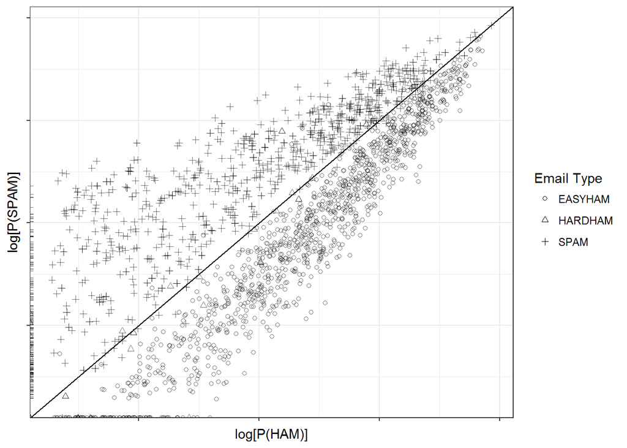

```r
# Create final plot of results
(class_plot <- ggplot(class_df, aes(x = log(Prob_HAM), log(Prob_SPAM))) +
    geom_point(aes(shape = Type, alpha = 0.5)) +
    geom_abline(intercept = 0, slope = 1) +
    scale_shape_manual(values = c("EASYHAM" = 1,
                                  "HARDHAM" = 2,
                                  "SPAM" = 3),
                       name = "Email Type") +
    scale_alpha(guide = "none") +
    xlab("log[P(HAM)]") +
    ylab("log[P(SPAM)]") +
    theme_bw() +
    theme(axis.text.x = element_blank(), axis.text.y = element_blank()))
```

This scatterplot is in **log-log** scale b/c many predicted probabilities are very tiny, while others are not. W/ this high degree of variance, it is difficult to compare results directly, so taking logs is a simple way of altering the visual scale to more easily compare values.

We have also added a simple decision boundary to the plots where y = x, the **perfect linear relationship**, b/c our classifier compares the 2 predicted probabilities + determines an email’s type based on whether probability of being spam is greater than that of ham. All dots above the black diagonal line, therefore, *should* be spam, + all those below should be ham.

Both of these observations may indicate a weak training data set for ham emails, as there are clearly many more terms that should be associated w/ ham that currently are not.

# Improving the Results

For a basic idea of text classification, we constructed a very simple **Naive Bayes classifier** using a minimal number of assumptions + features.

At its core, this type of classification is an application of classic conditional probability theory in a contemporary context. Despite the fact we trained our classifier w/ only a fraction of the total available data (1st 500 files in `ham`), this simple method performed reasonably well.

That said, the false-positive + false-negative rates found in the test data are far too high for any production spam filter. There are many simple tweaks we could apply to improve the results of the current model.

For example, our approach assumes a priori that each email has an equal probability of being ham or spam. In practice, however, we know that this relationship is actually much closer to 80%–20% ham-to-spam.

1 way we might improve results would be to simply **alter our prior beliefs** to reflect this fact and recalculate the predicted probabilities.

```r
# alter priors to better reflect reality of 80/20 ham/spam
spam_classifier_real <-function(path) {
  prob_spam <- classify_email(path, spam_df, prior = 0.2)
  prob_ham  <- classify_email(path, easyham_df, prior = 0.8)
 return(c(prob_spam, prob_ham, ifelse(prob_spam > prob_ham, 1, 0)))
}
```

Remember we left the `prior` parameter as something that could vary in `classify_email()`. We could rerun the classifier now + compare the results.

```
##                NOT SPAM       SPAM
## easyham2_col2 0.9864286 0.01357143
## hardham2_col2 0.9354839 0.06451613
## spam2_col2    0.2698640 0.73013601
```

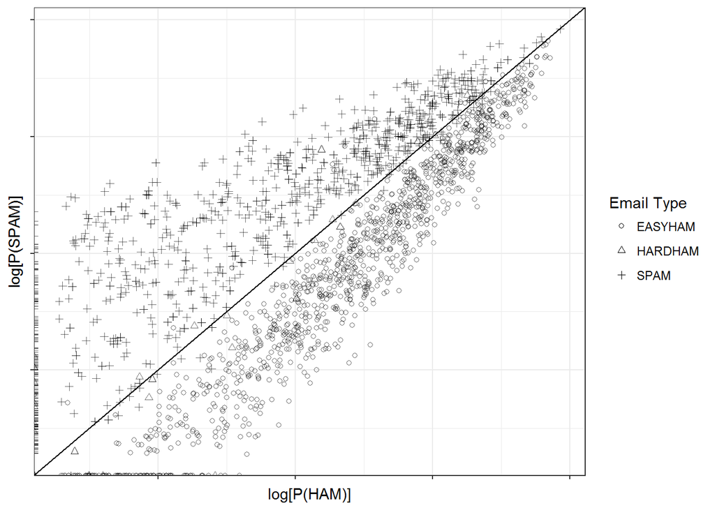

These new assumptions, however, violate the distributions of ham and spam messages in our training data. To be more accurate, we should go back and retrain the classifier with the *complete* easy ham data set (we limited our original ham training data to only the 1st 500 messages so that our training data would reflect the Bayesian assumptions).

In that vein, we must incorporate the full data set in order to reflect our new assumptions. When we rerun the classifier with the new easyham.df and classify.email parameterization, we see a notable improvement in performance on false-positives

```
##                NOT SPAM       SPAM
## easyham2_col2 0.9878571 0.01214286
## hardham2_col2 0.9556452 0.04435484
## spam2_col2    0.2927702 0.70722978
```

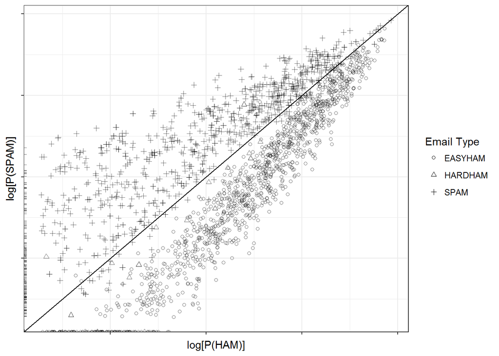

With these simple changes, we have reduced our false-positive rate again (down to 1.2% and 4.4%, but false-negative results suffer (up to 29%).

In essence, what we are doing is moving the decision boundaries and are explicitly trading off false positives for improvement in false negatives. This is an excellent example of why model specification is critical, and how each assumption and feature choice can affect all results.

Often it is difficult/impossible to classify observations based on a *single* decision boundary.